# Reproducible Research Course Project 1

David R

30/04/2020

This is the first course project for the Reproducible Research course.  
First, the following [repository](https://github.com/rdpeng/RepData_PeerAssessment1) was cloned containing the original dataset *activity.zip*. Then the csv file was manually unzipped and stored as *activity.csv* in the same folder.  
The follow paragraphs describe how the dataset was processed and basic metrics (mean, median) and plots (histograms) generated.

## Loading the data

Load the data via the *read.csv* function.

```r
activitydata<-read.csv("activity.csv")
```

## Calculate and visualize mean number of steps taken per day

First load dplyr package to make use of pipeline operator and functions such as group_by, summarize.  
Then load ggplot library.

```r
library(dplyr)
```

```r
library(ggplot2)
```

Next, sum totalsteps by day and store in new variable *aggActivity*.  
Then calculate mean of total steps per day.

```r
activitydata %>%as_tibble() %>%
                group_by(date) %>%
                summarize(totalsteps=sum(steps)) -> aggActivity

mean(aggActivity$totalsteps, na.rm=TRUE)
```

```
## [1] 10766.19
```

and same for the median:

```r
median(aggActivity$totalsteps, na.rm=TRUE)
```

```
## [1] 10765
```

Finally, plot a histogram of total steps per day:

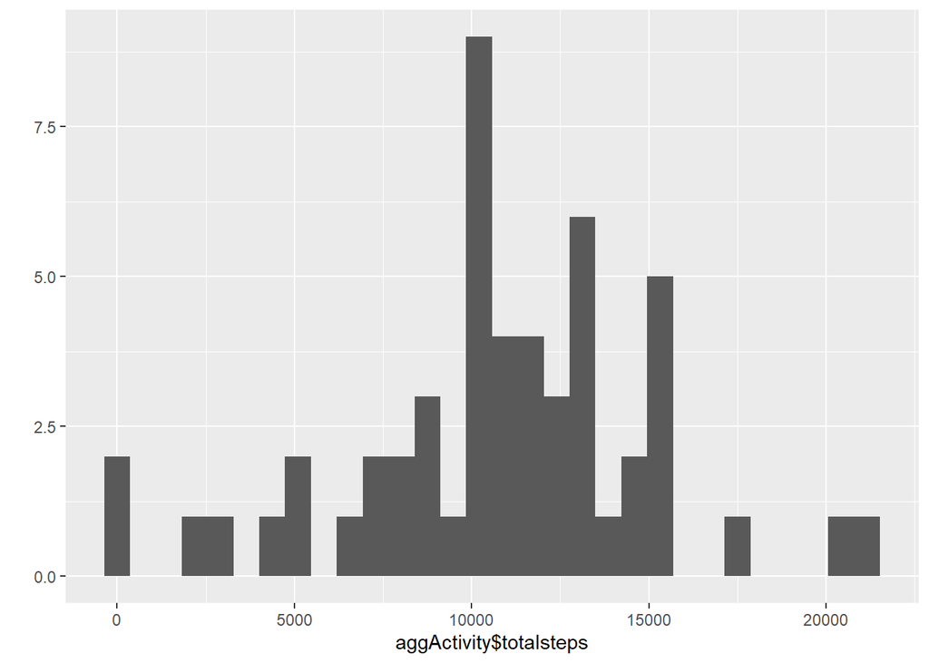

```r
qplot(aggActivity$totalsteps,geom="histogram")
```

## Average daily activity pattern

Let’s analyse how an avrg daily activity pattern looks like. We will summarize the data by interval, calculate the avrg number of steps done during the observation period and visualize it via a lineplot.

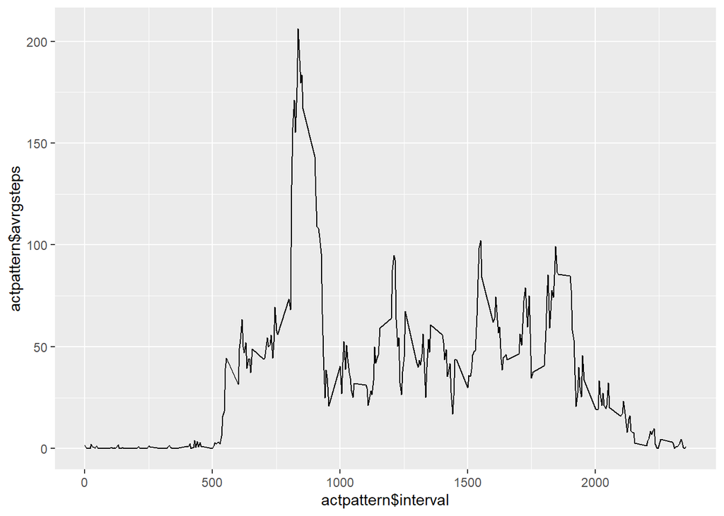

```r
activitydata %>%as_tibble() %>%
                group_by(interval) %>%
                summarize(avrgsteps=mean(steps,na.rm=TRUE)) -> actpattern
qplot(actpattern$interval, actpattern$avrgsteps,geom="line")
```

Looks like the highest activity can be observed in the morning before 10. Let’s check by returning the interval for which the avrgsteps column equals its maximum.

```r
actpattern$interval[actpattern$avrgsteps==max(actpattern$avrgsteps,na.rm=TRUE)]
```

```
## [1] 835
```

## Imputing missing values

Let’s deal with rows with NAs of which, as it turns out, there are quite a few:

```r
sum(is.na(activitydata$steps))
```

```
## [1] 2304
```

We will ‘fill’ these values by the average number of steps per 5 minute interval. This way, the mean steps should remain as with the original dataset. Firstly, let’s write a function which takes a vector, replaces all NAs with the average number of steps per 5 minute interval and returns the adjusted vector.

```r
naReplace<- function(inputColumn)
        {
        inputColumn[is.na(inputColumn)]<-mean(actpattern$avrgsteps)
        inputColumn
        }
```

Let’s see if this works

```r
naReplace(c(1,2,3,NA))
```

```
## [1]  1.0000  2.0000  3.0000 37.3826
```

Beautiful! Now let’s adjust the original dataset by overwriting all NAs by the same value and store it in a new dataframe *adj_activitydata*.

```r
activitydata %>% mutate(steps=naReplace(steps))->adj_activitydata
```

As a next step we will make histogram of the total number of steps taken each day of the adjusted dataset:

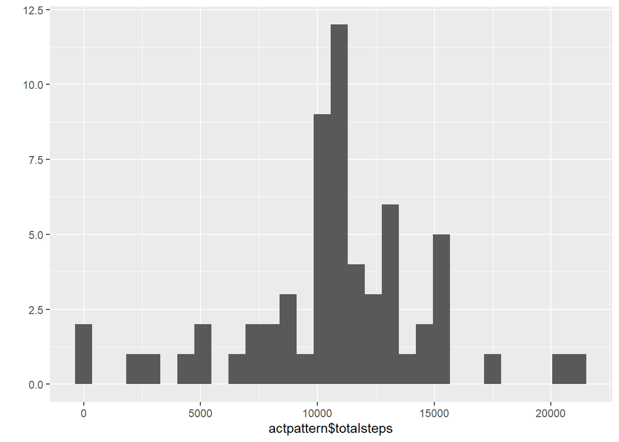

```r
adj_activitydata %>%as_tibble() %>%
                group_by(date) %>%
                summarize(totalsteps=sum(steps,na.rm=TRUE)) -> actpattern
qplot(actpattern$totalsteps,geom="histogram")
```

```r
mean(actpattern$totalsteps)
```

```
## [1] 10766.19
```

Now let’s check the median:

```r
median(actpattern$totalsteps)
```

```
## [1] 10766.19
```

```r
library(lubridate)
activitydata %>% mutate(date=ymd(date)) %>%
        mutate(daytype= as.factor(ifelse(wday(date)>6,"weekend","weekday")))->activitydata
```

Finally, let’s plot the average steps per interval seperately to identify potential patterns in the weekday / weekend data.

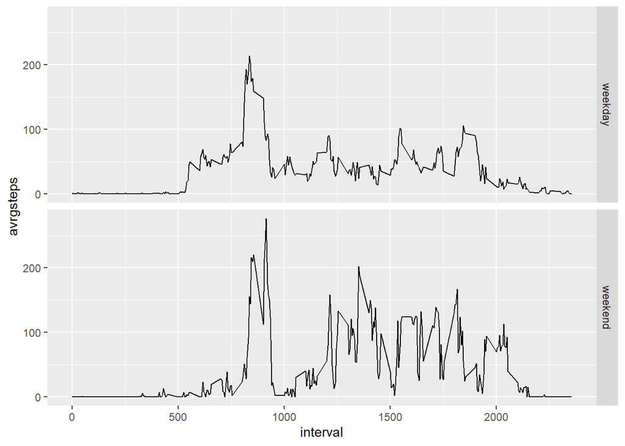

```r
activitydata %>% group_by(interval,daytype) %>%
        summarize(avrgsteps=mean(steps,na.rm=TRUE),date=first(date)) %>%
ggplot(aes(x=interval,y=avrgsteps))+geom_line()+facet_grid(daytype~.)
```